# RNASeq data processing

Hailey Hatch & Maggie Sogin

2026-07-01

# Introduction

This notebook processes metatranscriptomic (RNA-seq) data from an *Aiptasia* bacterial inoculation experiment. *Aiptasia* were first treated with antibiotics to reduce their native microbiome, then inoculated with one of three bacterial symbionts to examine changes in host, algal symbiont, and bacterial gene expression.

The script below aims to process data from RNA-Seq experiment and includes the following:

1. Load in data
2. Get Counts from featurecounts (saved)
3. Get TPM Counts (not saved)
4. QC plots
5. Clean and split tables, save by organism
6. Prepare annotations

At the end of this code, we save the following files for downstream analysis: - cleaned feature counts table per species - processed annotation files for aiptasia, bacteria and symbiodinium

**Previous pipeline:** Raw reads were processed with fastp (quality trimming) → SortMeRNA (rRNA removal) → HISAT2 (alignment to a combined reference genome containing *Aiptasia* host, *Symbiodiniaceae* symbiont, *Labrenzia*, *Ruegeria*, and *Vibrio*) → featureCounts (gene-level quantification).

# 1. Load Libraries & Define Constants

```r
library(readxl)
library(tidyverse)
library(DESeq2)
library(ggplot2)
library(pheatmap)
library(matrixStats)
library(ggrepel)
library(patchwork)
library(UpSetR)
library(stringr)
library(topGO)
library(vegan)
library(dplyr)
library("RColorBrewer")
library(scales)
```

```r
palette <- c(
  "FASW" = 'grey60',
  "ABS"     = 'black',
  "Labrenzia"    = '#A6CEE3',
  "Ruegeria"    = '#1F78B4',
  "Vibrio"    = '#B2DF8A',
  "multi"  = 'violet')
treatment_levels <- c(
  "control" = "FASW",
  "ABS" = "ABS",
  "ISOA" = "Labrenzia",
  "ISOB" = "Ruegeria",
  "ISOC" = "Vibrio",
  "ISOABC" = "multi")

path.out<-"../../output/transcriptomics"
path.in<-"../../data/transcriptomics"
```

# 2. Load All Data Files

```r
# featureCounts gene count matrix (6 annotation cols + 48 samples)
counts_raw <- read.delim(file.path(path.in,"counts.tsv"), comment.char = "#", check.names = FALSE)

# featureCounts assignment summary
counts_summary <- read.delim(file.path(path.in,"counts.tsv.summary"), check.names = FALSE)

# HISAT2 alignment rates
hisat2_sum <- read.delim(file.path(path.in,"hisat2_alignment_summary.tsv"))

# Per-reference organism read counts (aip, sym, lab, rue, vib)
organism_counts <- read.delim(file.path(path.in,"per_reference_counts.tsv"))

# SortMeRNA rRNA removal summary
sortme_sum <- read.delim(file.path(path.in,"sortmerna_summary.tsv"))

# Fastp trimming summary
fastp_sum <- read.delim(file.path(path.in,"fastp_summary_per_sample.tsv"), check.names = FALSE)

# Aiptasia gene annotations (SwissProt/TrEMBL BLAST, GO, KEGG)
aip_annotate <- read.delim(file.path(path.in,"Aiptasia_annotation_file.csv"))
length(aip_annotate$Protein_ID)
```

```
## [1] 36127
```

# 3. Build Sample Metadata

Create the `colData` data frame that DESeq2 requires. We’ll parse treatment and timepoint directly from the sample names so it’s fully reproducible.

```r
# Step 1: Make function to clean sample names
clean_sample_name <- function(x) {gsub("_S\\d+.*$", "", x)}

# Step 2: Get sample column names from the counts data
colnames(counts_raw) <- clean_sample_name(basename(colnames(counts_raw)))
annotation_cols <- c("Geneid", "Chr", "Start", "End", "Strand", "Length")
sample_names <- colnames(counts_raw)[!colnames(counts_raw) %in% annotation_cols]

# Step 3: Parse treatment and timepoint from the clean names
treatment <- str_extract(sample_names, "ISOABC|ISOA|ISOB|ISOC|ABS|control")
timepoint <- str_extract(sample_names, "\\d+dpi")

# Step 4: Create the colData data frame
colData <- data.frame(row.names = sample_names, treatment = treatment, timepoint = timepoint)

# Step 5: Convert treatment and timepoint to factors with your defined levels
colData$treatment <- factor(treatment_levels[as.character(colData$treatment)],
                            levels = treatment_levels)
colData$timepoint <- factor(colData$timepoint, levels = c("1dpi", "21dpi"))

stopifnot(all(table(colData$treatment, colData$timepoint) == 4))

# Make metadata by turning rownames into a regular column
metadata <- colData %>% rownames_to_column("sample")

# save colData

write.csv(colData, file.path(path.out,'colData.csv'))
```

# 4. QC Summary Plots

Visualize pipeline quality metrics to identify any problematic samples before DESeq2.

## 4.1 Fastp — Read Quality & Trimming

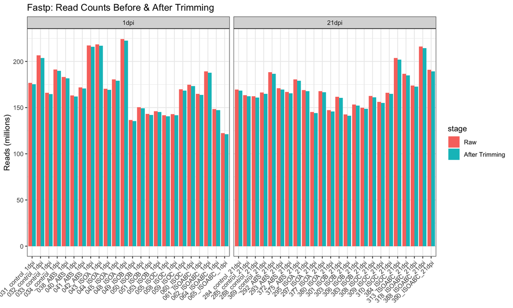

```r
plot_QC_fastp <- fastp_sum %>%
  mutate(sample = clean_sample_name(sample)) %>%
  left_join(metadata, by = "sample") %>%
  filter(!is.na(treatment)) %>%
  arrange(treatment, timepoint) %>%
  mutate(sample = fct_inorder(sample)) %>%
  dplyr::select(sample, treatment, timepoint, reads_before, reads_after) %>%
  pivot_longer(cols = c(reads_before, reads_after),
               names_to = "stage", values_to = "reads") %>%
  mutate(stage = factor(stage, levels = c("reads_before", "reads_after"),
                        labels = c("Raw", "After Trimming"))) %>%
  ggplot(aes(x = sample, y = reads / 1e6, fill = stage)) +
  geom_col(position = "dodge") +
  facet_wrap(~ timepoint, scales = "free_x") +
  theme_bw() +
  theme(axis.text.x = element_text(angle = 45, hjust = 1)) +
  labs(title = "Fastp: Read Counts Before & After Trimming",
       y = "Reads (millions)", x = NULL)
plot_QC_fastp
```

```r
# No extreme trimming; all samples ~125-225M reads
```

## 4.2 SortMeRNA — rRNA Removal Rates

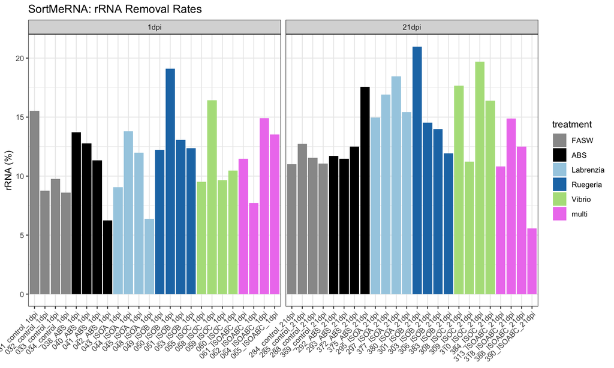

```r
plot_QC_sortmerna <- sortme_sum %>%
  mutate(sample = clean_sample_name(sample)) %>%
  left_join(metadata, by = "sample") %>%
  arrange(treatment, timepoint) %>%
  mutate(sample = fct_inorder(sample)) %>%
  ggplot(aes(x = sample, y = rRNA_pct, fill = treatment)) +
  geom_col() +
  facet_wrap(~ timepoint, scales = "free_x") +
  scale_fill_manual(values = palette) +
  theme_bw() +
  theme(axis.text.x = element_text(angle = 45, hjust = 1)) +
  labs(title = "SortMeRNA: rRNA Removal Rates", y = "rRNA (%)", x = NULL)
plot_QC_sortmerna
```

```r
# ~5-20% rRNA; 21dpi slightly higher on average
```

## 4.3 HISAT2 — Alignment Rates

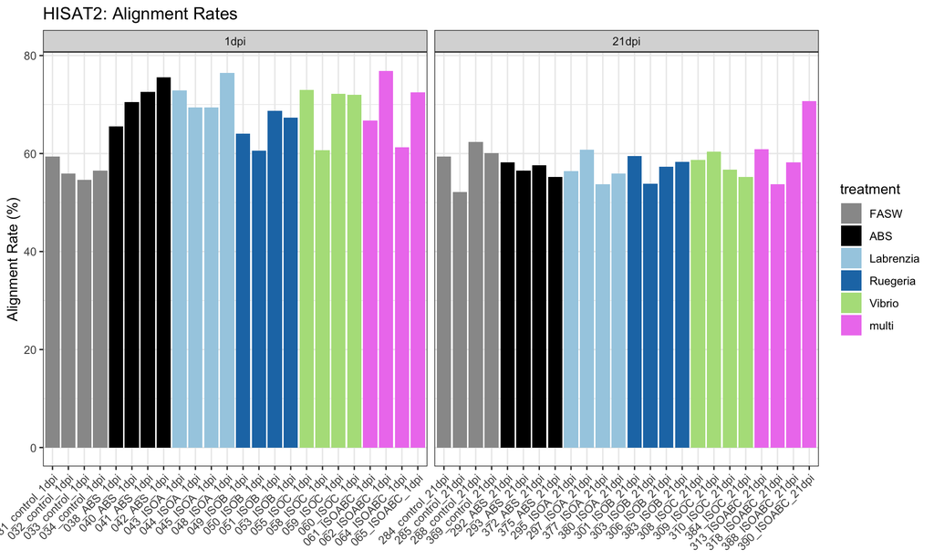

```r
plot_QC_hisat2 <- hisat2_sum %>%
  mutate(sample = clean_sample_name(sample)) %>%
  left_join(metadata, by = "sample") %>%
  arrange(treatment, timepoint) %>%
  mutate(sample = fct_inorder(sample)) %>%
  ggplot(aes(x = sample, y = `overall_alignment_rate...`, fill = treatment)) +
  geom_col() +
  facet_wrap(~ timepoint, scales = "free_x") +
  scale_fill_manual(values = palette) +
  theme_bw() +
  theme(axis.text.x = element_text(angle = 45, hjust = 1)) +
  labs(title = "HISAT2: Alignment Rates", y = "Alignment Rate (%)", x = NULL)
plot_QC_hisat2
```

```r
# Alignment rates 50-75%
```

## 4.4 % Library Mapped to Each Genome

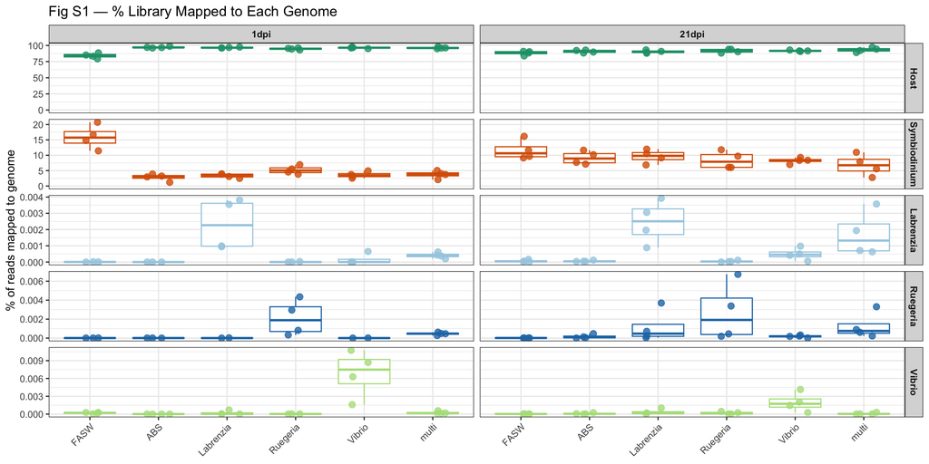

```r
# Compute % of total mapped reads assigned to each organism per sample
figS1_data <- organism_counts %>%
  mutate(sample = clean_sample_name(sample)) %>%
  left_join(metadata, by = "sample") %>%
  mutate(total = aip + sym + lab + rue + vib) %>%
  pivot_longer(cols = c(aip, sym, lab, rue, vib),
               names_to = "organism", values_to = "reads") %>%
  mutate(pct_mapped = 100 * reads / total,
         organism = factor(organism,
                           levels = c("aip", "sym", "lab", "rue", "vib"),
                           labels = c("Host", "Symbiodinium", "Labrenzia", "Ruegeria", "Vibrio")),
         treatment = factor(treatment, levels = treatment_levels))

plot_figS1 <- ggplot(figS1_data, aes(x = treatment, y = pct_mapped, color = organism)) +
  geom_boxplot(outlier.shape = NA, alpha = 0.7) +
  geom_jitter(width = 0.2, size = 2.5, alpha = 0.8) +
  facet_grid(organism ~ timepoint, scales = "free_y") +
  scale_color_manual(values = c("Host" = "#1b9e77", "Symbiodinium" = "#d95f02",
                                "Labrenzia" = "#A6CEE3", "Ruegeria" = "#1F78B4",
                                "Vibrio" = "#B2DF8A")) +
  ylim(0, NA) +
  theme_bw() +
  theme(axis.text.x = element_text(angle = 45, hjust = 1),
        legend.position = "none",
        strip.text = element_text(face = "bold")) +
  labs(title = "Fig S1 — % Library Mapped to Each Genome",
       y = "% of reads mapped to genome", x = NULL)
plot_figS1
```

```r
ggsave(file.path(path.out,"Fig_pct_mapped_by_genome.pdf"), plot_figS1, width = 12, height = 6)
ggsave(file.path(path.out,"Fig_pct_mapped_by_genome.png"), plot_figS1, width = 12, height = 6, dpi = 300)
```

## 4.5 featureCounts — Read Assignment Summary

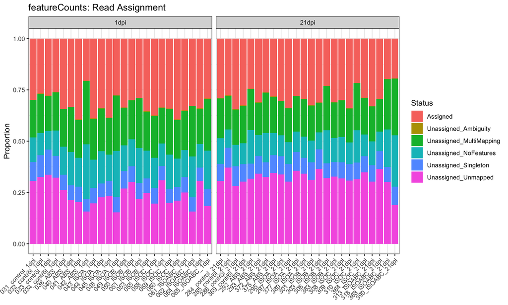

```r
colnames(counts_summary) <- clean_sample_name(basename(colnames(counts_summary)))

fc_data <- counts_summary %>%
  pivot_longer(cols = -Status, names_to = "sample", values_to = "reads") %>%
  filter(reads > 0) %>%
  left_join(metadata, by = "sample") %>%
  arrange(treatment, timepoint) %>%
  mutate(sample = fct_inorder(sample))

plot_QC_featurecounts <- ggplot(fc_data, aes(x = sample, y = reads, fill = Status)) +
  geom_col(position = "fill") +
  facet_wrap(~ timepoint, scales = "free_x") +
  theme_bw() +
  theme(axis.text.x = element_text(angle = 45, hjust = 1)) +
  labs(title = "featureCounts: Read Assignment", y = "Proportion", x = NULL)
plot_QC_featurecounts
```

```r
# Assigned reads ~25% — low but expected for metatranscriptomic reference
```

## 4.6 featureCounts — Library Size

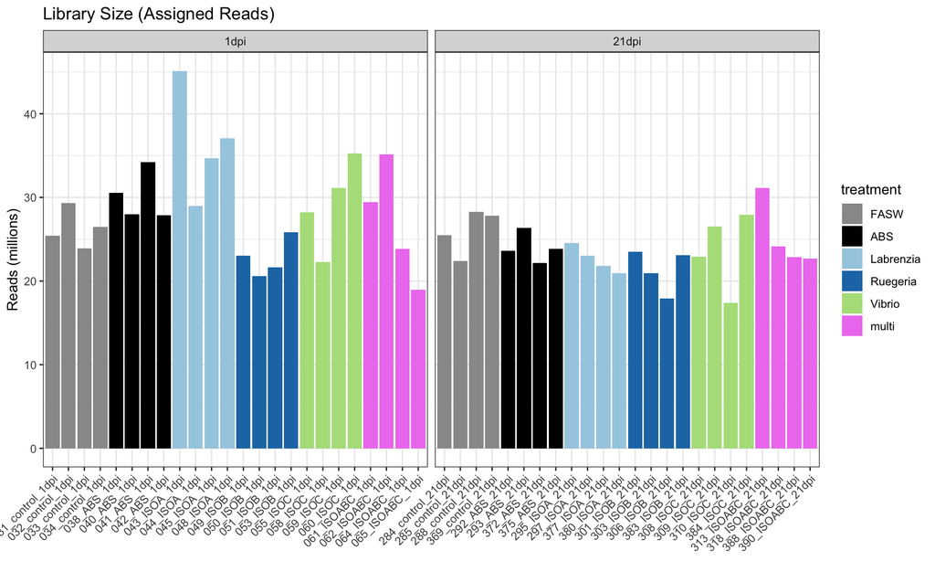

```r
plot_QC_library_size <- fc_data %>%
  filter(Status == "Assigned") %>%
  ggplot(aes(x = sample, y = reads / 1e6, fill = treatment)) +
  geom_col() +
  facet_wrap(~ timepoint, scales = "free_x") +
  scale_fill_manual(values = palette) +
  theme_bw() +
  theme(axis.text.x = element_text(angle = 45, hjust = 1)) +
  labs(title = "Library Size (Assigned Reads)", y = "Reads (millions)", x = NULL)
plot_QC_library_size
```

```r
# ~20-40M reads assigned to combined reference per sample
```

## 4.7 Save QC Plots

```r
qc_plots <- list(
  "plot_QC_fastp"         = plot_QC_fastp,
  "plot_QC_sortmerna"     = plot_QC_sortmerna,
  "plot_QC_hisat2"        = plot_QC_hisat2,
  "plot_QC_featurecounts" = plot_QC_featurecounts,
  "plot_QC_library_size"  = plot_QC_library_size)

for (name in names(qc_plots)) {
  ggsave(filename = file.path(path.out,paste0(name, ".pdf")),
         plot = qc_plots[[name]],
         width = 10, height = 6)

  ggsave(filename = file.path(path.out,paste0(name, ".png")),
         plot = qc_plots[[name]],
         width = 10, height = 6, dpi = 300)
}
```

# 5. Clean and Prepare the Count Matrix

Transform the raw featureCounts output into a clean integer count matrix that DESeq2 can use.

```r
# Save gene lengths for TPM calculation later
gene_lengths <- counts_raw %>%
                dplyr::select(Geneid, Length) %>% column_to_rownames("Geneid")

counts_matrix <- counts_raw %>%
  dplyr::select(-Chr, -Start, -End, -Strand, -Length) %>%
  column_to_rownames("Geneid") %>%
  as.matrix()
counts_matrix <- round(counts_matrix)

all(colnames(counts_matrix) == rownames(colData))
```

```
## [1] TRUE
```

```r
dim(counts_matrix)
```

```
## [1] 89805    48
```

```r
head(counts_matrix)
```

```
##        031_control_1dpi 032_control_1dpi 033_control_1dpi 034_control_1dpi
## aip_g1              306              314              163              444
## aip_g2              645              693              453              882
## aip_g3               24               39               17               41
## aip_g4              211              249              106              273
## aip_g5             5588             6322             4744             6049
## aip_g6              262              337              223              308
##        038_ABS_1dpi 040_ABS_1dpi 041_ABS_1dpi 042_ABS_1dpi 043_ISOA_1dpi
## aip_g1          215          429          219         1479           419
## aip_g2          561          767          743         1844          1015
## aip_g3           26           61           13          250            21
## aip_g4          206          228          295          561           311
## aip_g5         6915         6952         8388         7563         11334
## aip_g6          400          357          415          540           690
##        044_ISOA_1dpi 045_ISOA_1dpi 048_ISOA_1dpi 049_ISOB_1dpi 050_ISOB_1dpi
## aip_g1           258           190          1120           329           193
## aip_g2           549           581          1574           647           394
## aip_g3            54             6           122            12            39
## aip_g4           264           282           638           143           198
## aip_g5          6601          7515          9845          5765          4475
## aip_g6           420           467           625           380           230
##        051_ISOB_1dpi 053_ISOB_1dpi 055_ISOC_1dpi 058_ISOC_1dpi 059_ISOC_1dpi
## aip_g1           332           215           252            59           393
## aip_g2           539           477           651           234           920
## aip_g3            88            21            27            15            43
## aip_g4           182           172           203           264           349
## aip_g5          5251          5691          7132          4163          7855
## aip_g6           344           349           412           318           468
##        060_ISOC_1dpi 061_ISOABC_1dpi 062_ISOABC_1dpi 064_ISOABC_1dpi
## aip_g1           227             233             678              81
## aip_g2           614             549            1137             245
## aip_g3            23              17             106              29
## aip_g4           261             225             349             194
## aip_g5          7661            6426            9058            4379
## aip_g6           485             333             533             362
##        065_ISOABC_1dpi 284_control_21dpi 285_control_21dpi 288_control_21dpi
## aip_g1             353               330               253               228
## aip_g2             570               614               547               626
## aip_g3              59                43                15                10
## aip_g4             214               219               140               294
```

[output cut: 22 more lines]

```
## aip_g6            255              404              340               409
##        372_ABS_21dpi 375_ABS_21dpi 377_ISOA_21dpi 380_ISOA_21dpi 383_ISOB_21dpi
## aip_g1           243           202            179            119            173
## aip_g2           475           600            528            299            616
## aip_g3            49            24             14             23             13
## aip_g4           288           197            157            194            236
## aip_g5          5436          5838           4959           4183           5702
## aip_g6           362           263            254            321            318
##        384_ISOC_21dpi 388_ISOABC_21dpi 390_ISOABC_21dpi
## aip_g1            169              775             1010
## aip_g2            490             1121             1305
## aip_g3             19              137              161
## aip_g4            198              397              503
## aip_g5           6212             5882             6982
## aip_g6            410              389              465
```

## 5.1 Compute TPM Matrix

TPM (Transcripts Per Million) normalizes for both gene length and sequencing depth, making expression values comparable across samples AND genes

TPM formula: for each gene in each sample, 1. Divide raw count by gene length in kb → RPK (reads per kilobase) 2. Sum all RPKs in that sample → scaling factor 3. Divide each RPK by (scaling factor / 1e6) → TPM

```r
all(rownames(gene_lengths) == rownames(counts_matrix))
```

```
## [1] TRUE
```

```r
gene_lengths_kb <- gene_lengths$Length / 1000

rpk_matrix <- sweep(counts_matrix, 1, gene_lengths_kb, "/")

scaling_factors <- colSums(rpk_matrix)

tpm_matrix <- sweep(rpk_matrix, 2, scaling_factors / 1e6, "/")

tpm_aip <- tpm_matrix[startsWith(rownames(tpm_matrix), "aip_"), ]
tpm_sym <- tpm_matrix[startsWith(rownames(tpm_matrix), "sym_"), ]
tpm_lab <- tpm_matrix[startsWith(rownames(tpm_matrix), "lab_"), ]
tpm_rue <- tpm_matrix[startsWith(rownames(tpm_matrix), "rue_"), ]
tpm_vib <- tpm_matrix[startsWith(rownames(tpm_matrix), "vib_"), ]

dim(tpm_aip)
```

```
## [1] 30953    48
```

# 6. Split Counts by Organism

```r
counts_aip <- counts_matrix[startsWith(rownames(counts_matrix), "aip_"), ]
counts_sym <- counts_matrix[startsWith(rownames(counts_matrix), "sym_"), ]
counts_lab <- counts_matrix[startsWith(rownames(counts_matrix), "lab_"), ]
counts_rue <- counts_matrix[startsWith(rownames(counts_matrix), "rue_"), ]
counts_vib <- counts_matrix[startsWith(rownames(counts_matrix), "vib_"), ]

# Verify splits include all counts
nrow(counts_aip) + nrow(counts_sym) + nrow(counts_lab) + nrow(counts_rue) + nrow(counts_vib) == nrow(counts_matrix)
```

```
## [1] TRUE
```

Gene filtering - Below calculate the Nr of genes passing the filter, a gene is included in the filter if it has at least 10 reads in 4 samples across the entire dataset (Ref: deseq manual )

```r
organism_list <- list(
  aip = counts_aip, sym = counts_sym,
  lab = counts_lab, rue = counts_rue, vib = counts_vib)

organism_summary <- data.frame(
  organism = names(organism_list),
  total_genes = sapply(organism_list, nrow),
  median_counts_per_sample = sapply(organism_list, function(x) median(colSums(x))), #median nr. reads mapping to each sample
  genes_all_zero = sapply(organism_list, function(x) sum(rowSums(x) == 0)), #nr genes no expression data at all
  genes_passing_filter = sapply(organism_list, function(x) sum(rowSums(x >= 10) >= 4)) # at least 10 counts in 4 samps
)
organism_summary
```

```
##     organism total_genes median_counts_per_sample genes_all_zero
## aip      aip       30953               23952479.0            332
## sym      sym       43403                 472279.5          16329
## lab      lab        5920                     15.5           2717
## rue      rue        4669                     17.0           2801
## vib      vib        4860                      4.0           2527
##     genes_passing_filter
## aip                29680
## sym                12921
## lab                    0
## rue                    3
## vib                   19
```

```r
# Few bacterial genes passed the filter
```

```r
for (name in names(organism_list)) {
  write.csv(organism_list[[name]],
            file = file.path(path.out, paste0("counts_", name, ".csv")),
            quote = FALSE, row.names = TRUE)
}
```

# 7. Prepare Annotation Data

The annotation file has multiple transcript isoforms per gene (e.g., g1.t1 and g1.t2 are isoforms of gene g1). We need to:

1. Extract the gene-level ID
2. Match it to the count matrix format (with `aip_` prefix)
3. Deduplicate to one annotation per gene

## 7.1 Parse Aiptasia annotations

```r
# Step 1: Extract gene ID from Protein_ID
aip_annotate <- aip_annotate %>%
  mutate(gene_id = paste0("aip_", sub("\\..*$", "", Protein_ID)))
aip_annotate_full<-aip_annotate

# Step 2: Extract a short protein name from the SwissProt BLAST hit column
aip_annotate <- aip_annotate %>%
  mutate(protein_name = str_extract(`BLAST_hit..SwissProt.`, "(?<=\\|)[^|]+(?=_)"))

# Step 3: Deduplicate — keep one row per gene_id
# aip_annotate <- aip_annotate %>%
#   group_by(gene_id) %>%
#   slice_min(`E.value..SwissProt.`, n = 1, with_ties = FALSE, na.rm=T) %>%
#   ungroup()

aip_annotate <- aip_annotate %>%
  group_by(gene_id) %>%
  slice_min(`E.value..SwissProt.`, n = 1, with_ties = FALSE) %>%
  ungroup()

# Step 4: Select key columns for the final annotation table: gene_id, protein_name, BLAST description, GO terms, KEGG_ID
aip_annotate <- aip_annotate %>%
  dplyr::select(gene_id, protein_name, Protein_ID,
         starts_with("Hit_description"),
         starts_with("GO_"),
         KEGG_ID)


length(unique(aip_annotate$gene_id))
```

```
## [1] 30953
```

```r
#Step 5: Save annotation file
write.csv(aip_annotate, file = file.path(path.out,"aip_annotate.csv"))
```

## 7.2 Parse Bacterial Annotations from GFF3

The three bacterial genomes were annotated with [Bakta](https://github.com/oschwengers/bakta). The GFF3 files contain rich `Name=` (product), `gene=`, `KEGG:`, and `COG:` fields in the attributes column. We parse CDS features to build annotation tables matching the count matrix gene IDs (`lab_AODPDA_XXXXX`, `rue_LDIBIJ_XXXXX`, `vib_BPEJFA_XXXXX`).

```r
parse_bakta_gff3 <- function(gff3_path, prefix) {
  lines <- readLines(gff3_path)
  lines <- lines[!grepl("^#", lines) & nchar(lines) > 0]

  gff <- read.delim(textConnection(lines), header = FALSE,
                    col.names = c("seqid","source","type","start","end",
                                  "score","strand","phase","attributes"))

  gff_cds <- gff %>% filter(type == "CDS")

  gff_cds <- gff_cds %>%
    mutate(
      locus_tag  = str_extract(attributes, "(?<=locus_tag=)[^;]+"),
      gene_name  = str_extract(attributes, "(?<=;gene=|^gene=)[^;]+"),
      product    = str_extract(attributes, "(?<=Name=)[^;]+") %>% URLdecode(),
      kegg       = str_extract(attributes, "(?<=KEGG:)[^,;]+"),
      cog_id     = str_extract(attributes, "(?<=COG:COG)\\d+") %>%
                     {ifelse(is.na(.), NA, paste0("COG", .))},
      go_terms   = str_extract(attributes, "(?<=Dbxref=).*") %>%
                     str_extract_all("GO:\\d+") %>%
                     sapply(function(x) paste(x, collapse = ";"))
    ) %>%
    mutate(
      gene_id = paste0(prefix, "_", locus_tag),
      go_terms = ifelse(go_terms == "", NA, go_terms)
    ) %>%
    dplyr::select(gene_id, locus_tag, gene_name, product, kegg, cog_id, go_terms) %>%
    distinct(gene_id, .keep_all = TRUE)

  return(gff_cds)
}

annot_lab <- parse_bakta_gff3(file.path(path.in,"labrenzia.gff3"), "lab")
annot_rue <- parse_bakta_gff3(file.path(path.in,"ruegeria.gff3"),  "rue")
annot_vib <- parse_bakta_gff3(file.path(path.in,"vibrio.gff3"), "vib")

annot_bact <- bind_rows(
  annot_lab %>% mutate(organism = "Labrenzia"),
  annot_rue %>% mutate(organism = "Ruegeria"),
  annot_vib %>% mutate(organism = "Vibrio")
)

cat("Labrenzia:", nrow(annot_lab), "CDS,", sum(!is.na(annot_lab$gene_name)), "with gene names,",
    sum(!is.na(annot_lab$kegg)), "with KEGG\n")
```

```
## Labrenzia: 5844 CDS, 4103 with gene names, 1019 with KEGG
```

```r
cat("Ruegeria:", nrow(annot_rue), "CDS,", sum(!is.na(annot_rue$gene_name)), "with gene names,",
    sum(!is.na(annot_rue$kegg)), "with KEGG\n")
```

```
## Ruegeria: 4587 CDS, 3014 with gene names, 730 with KEGG
```

```r
cat("Vibrio:", nrow(annot_vib), "CDS,", sum(!is.na(annot_vib$gene_name)), "with gene names,",
    sum(!is.na(annot_vib$kegg)), "with KEGG\n")
```

```
## Vibrio: 4666 CDS, 2545 with gene names, 796 with KEGG
```

```r
#save annotation file
write.csv(annot_bact, file = file.path(path.out,'annot_bact.csv'))
```

## 7.3 Parse Symbiont Annotations from Combined GTF

The *Symbiodiniaceae* genes in the combined GTF have `gene` and `product` attributes on transcript lines. We extract one annotation per gene_id.

```r
gtf_lines <- readLines(file.path(path.in,"combined_annotation.gtf"))
sym_transcript_lines <- gtf_lines[grepl("^sym_", gtf_lines) & grepl("\\ttranscript\\t", gtf_lines)]

annot_sym <- data.frame(raw = sym_transcript_lines, stringsAsFactors = FALSE) %>%
  mutate(
    gene_id   = str_extract(raw, 'gene_id "([^"]+)"', group = 1),
    gene_name = str_extract(raw, 'gene "([^"]+)"', group = 1),
    product   = str_extract(raw, 'product "([^"]+)"', group = 1)
  ) %>%
  dplyr::select(-raw) %>%
  filter(!is.na(gene_id)) %>%
  distinct(gene_id, .keep_all = TRUE)

# Create a label column: prefer gene_name, then non-hypothetical product, then gene_id
annot_sym <- annot_sym %>%
  mutate(label = case_when(
    !is.na(gene_name) ~ gene_name,
    !is.na(product) & product != "hypothetical protein" ~ str_trunc(product, 40),
    TRUE ~ gene_id
  ))

cat("Symbiont:", nrow(annot_sym), "genes,",
    sum(!is.na(annot_sym$gene_name)), "with gene names,",
    sum(!is.na(annot_sym$product) & annot_sym$product != "hypothetical protein"),
    "with non-hypothetical products\n")
```

```
## Symbiont: 43403 genes, 12195 with gene names, 14763 with non-hypothetical products
```

```r
#save annotation file
write.csv(annot_sym, file = file.path(path.out,'annot_sym.csv'))
```

# 8. Save data

```r
save(list=c('aip_annotate', 'counts_aip', 'colData'),file = file.path(path.out,'host_data.RData'))
```